# Project Foundations for Data Science: FoodHub Data Analysis

# **Question 6:** Explore all the variables and provide observations on their distributions. (Generally, histograms, boxplots, countplots, etc. are used for univariate exploration.) [9 marks]

customer_id:

restaurant_name:

cuisine_type:

cost_of_the_order

day_of_the_week

rating

food_preparation_time

delivery_time

### **Question 7**: Which are the top 5 restaurants in terms of the number of orders received? [1 mark]

```python
# We can see that the plot is rather cluttered, so we can use value_counts to
# get more useful info
df["restaurant_name"].value_counts()
```

```
Shake Shack                  219
The Meatball Shop            132
Blue Ribbon Sushi            119
Blue Ribbon Fried Chicken     96
Parm                          68
                            ...
Sushi Choshi                   1
Dos Caminos Soho               1
La Follia                      1
Philippe Chow                  1
'wichcraft                     1
Name: restaurant_name, Length: 178, dtype: int64
```

#### Observations:

Shake Shack: 219

The Meatball Shop: 132

Blue Ribbon Sushi: 119

Blue Ribbon Fried Chicken: 96

Parm: 68

### **Question 8**: Which is the most popular cuisine on weekends? [1 mark]

```python
# Get most popular cuisine on weekends
df_weekend = df[df['day_of_the_week'] == 'Weekend']
#this will check the unique value counts for cuisines on weekends
df_weekend['cuisine_type'].value_counts()
```

```
American          415
Japanese          335
Italian           207
Chinese           163
Mexican            53
Indian             49
Mediterranean      32
Middle Eastern     32
Thai               15
French             13
Korean             11
Southern           11
Spanish            11
Vietnamese          4
Name: cuisine_type, dtype: int64
```

Observations: It's clear by looking at the value counts that, similar to the entire data set, American cuisine is the most popular on the weekends, followed by Japanese and Italian.

### **Question 9**: What percentage of the orders cost more than 20 dollars? [2 marks]

```python
df_greater_than_20 = df[df["cost_of_the_order"]>20]
print(df_greater_than_20.shape[0])
fraction = df_greater_than_20.shape[0] / df.shape[0]
percentage = fraction * 100
print(percentage)
```

```
555
29.24130663856691
```

#### Observations:

We can see that a total of 555 orders cost more than 20 dollars, and by dividing that by the total number of orders, that the percentage of orders costing more than 20 dollars is roughly 29.24%

### **Question 10**: What is the mean order delivery time? [1 mark]

```python
#By using the df['column_name'].mean() function, we can find this data
df['delivery_time'].mean()
```

```
24.161749209694417
```

#### Observations:

Roughly 24.16 minutes

### **Question 11:** The company has decided to give 20% discount vouchers to the top 3 most frequent customers. Find the IDs of these customers and the number of orders they placed. [1 mark]

```python
#By taking the value counts and getting the top 3 with head(3), we will find the
#3 customers who placed the most orders
df['customer_id'].value_counts().head(3)
```

```
52832    13
47440    10
83287     9
Name: customer_id, dtype: int64
```

#### Observations:

Customer 52832 placed 13 orders

Customer 47440 placed 10 orders

Customerr 83287 placed 9 orders

### **Question 12**: Perform a multivariate analysis to explore relationships between the important variables in the dataset. (It is a good idea to explore relations between numerical variables as well as relations between numerical and categorical variables) [10 marks]

#### Cuisine Vs Cost

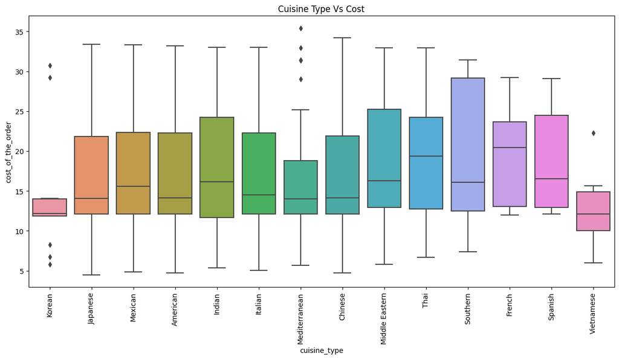

```python
plt.figure(figsize = (15, 7))
plt.xticks(rotation = 90)
plt.title("Cuisine Type Vs Cost")
sns.boxplot(x = "cuisine_type", y = "cost_of_the_order", data = df)
```

#### Cuisine Vs Rating

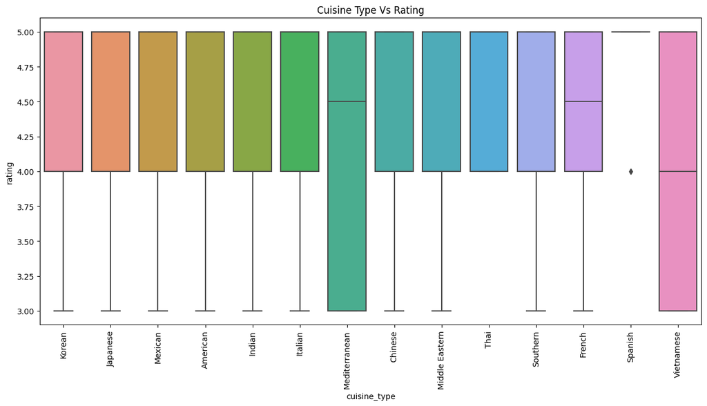

```python
plt.figure(figsize = (15, 7))
plt.xticks(rotation = 90)
plt.title("Cuisine Type Vs Rating")
sns.boxplot(data = df, x = "cuisine_type", y = "rating")
```

#### Cuisine VS Food Preparation Time

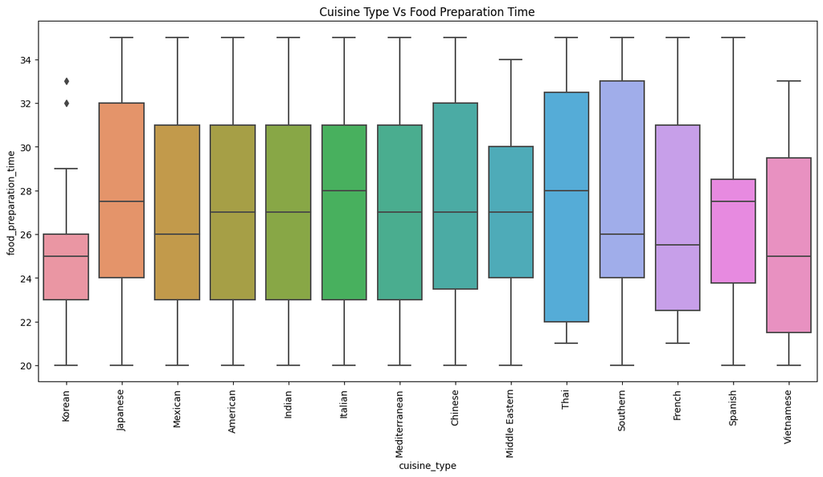

```python
plt.figure(figsize = (15, 7))
plt.xticks(rotation = 90)
plt.title("Cuisine Type Vs Food Preparation Time")
sns.boxplot(data = df, x = "cuisine_type", y = "food_preparation_time")
```

#### Rating Vs Cost

##### We can see the relationship between the cost and rating with a pointplot. Looking at the visualization, we see that higher rated meals tend to cost a little bit more, but only by less than a dollar.

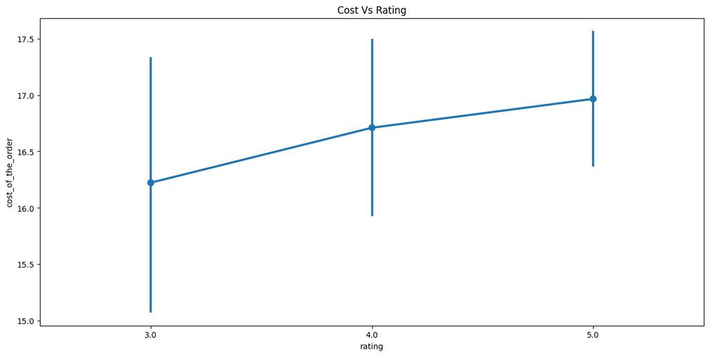

```python
plt.figure(figsize = (15, 7))
plt.title("Cost Vs Rating")
sns.pointplot(data = df, x = "rating", y = "cost_of_the_order")
plt.show()
```

#### Day of The Week Vs Delivery Time

##### We can see relationship between the weekends and weekdays and whether the delivery time might change, on average. Looking at the pointplot, we can see that the delivery time is much higher on weekdays than the weekends, perhaps because of rush hour or the work week.

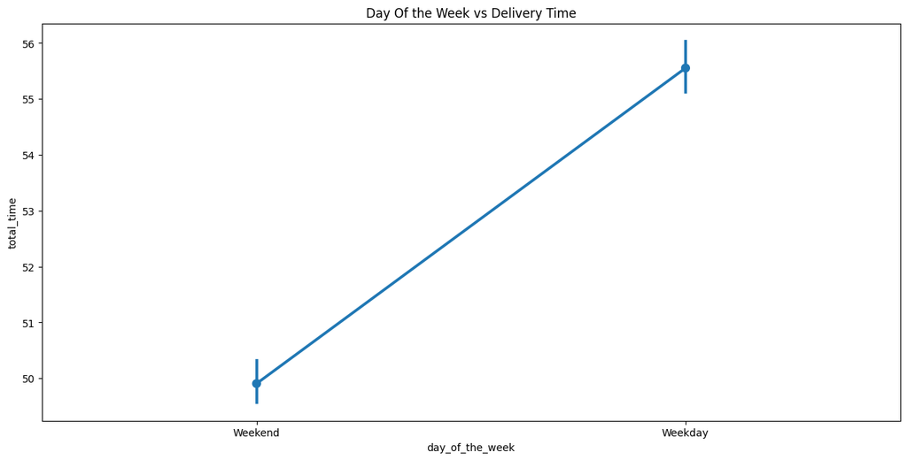

```python
plt.figure(figsize = (15, 7))
plt.title("Day Of the Week vs Delivery Time")
sns.pointplot(data = df, x = "day_of_the_week", y = "total_time")
plt.show()
```

#### Day Of The Week Vs Prep Time

#### We can look at a boxplot to see if the prep time may change depending on whether it's a weekday or weekend. Looking at the boxplot, we can see that there is no noticeable change in prep time depending on the day of the week the order is placed, so it looks like there are no specific days when restaurants get significantly more orders and their prep time suffers as a result.

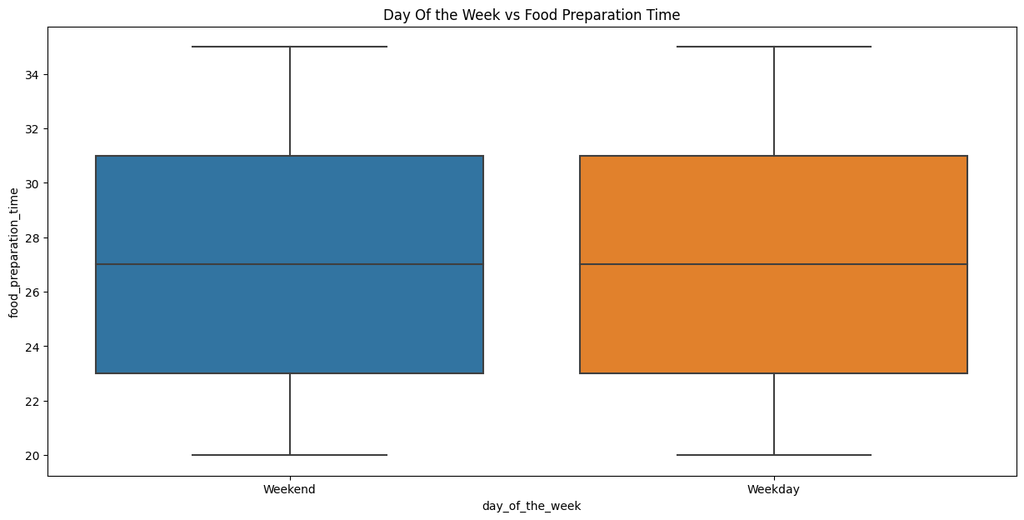

```python
plt.figure(figsize = (15, 7))
plt.title("Day Of the Week vs Food Preparation Time")
sns.boxplot(data = df, x = "day_of_the_week", y = "food_preparation_time")
plt.show()
```

#### Rating Vs Total Time

##### We can see if the rating may change depending on how long it takes for someone to get their order once they've placed it. By looking at the pointplot, we can see that, as we may anticipate, orders that take the longest on average have the lowest ratings (not by much). However, we can see that between 4.0 ratings and 5.0 ratings we don't see the total time it takes for the customer to get their order causing much of an issue. This leads us to believe that the difference between a 4.0 and 5.0 rating is based on the quality of the food, among other possible factors.

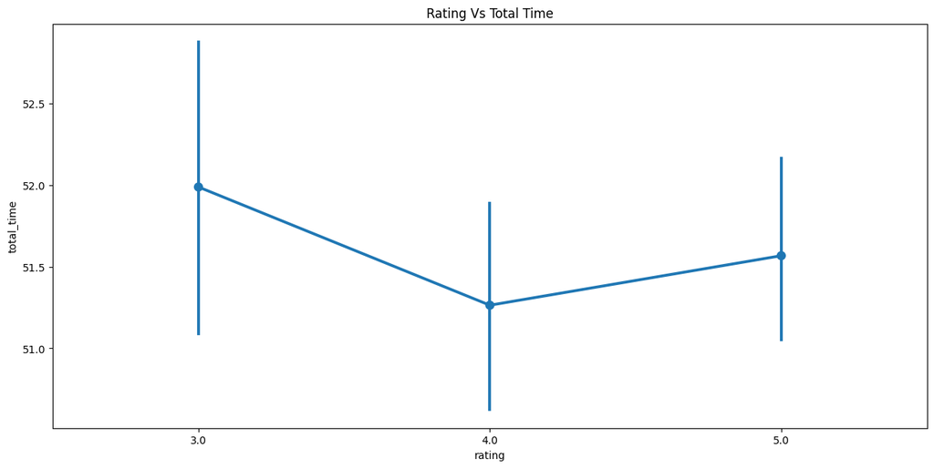

```python
plt.figure(figsize = (15, 7))
plt.title("Rating Vs Total Time")
sns.pointplot(data = df, x = "rating", y = "total_time")
plt.show()
```

#### Correlation among Variables

##### We can also plot a heatmap to see if there are any possible correlations between cost, rating and total time. Looking at the heatmap, we see that the correlations are between 0.03 and 0.01, so there is almost no linear association between these variables given the dataset

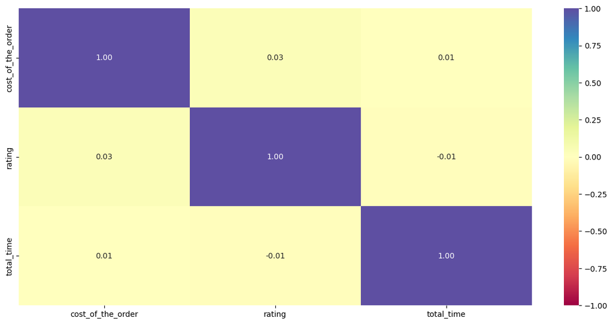

```python
col_list = ['cost_of_the_order', 'rating', 'total_time']
plt.figure(figsize=(15, 7))
sns.heatmap(df[col_list].corr(), annot=True, vmin = -1, vmax = 1, fmt = ".2f", cmap = "Spectral")
plt.show()
```

### **Question 13:** The company wants to provide a promotional offer in the advertisement of the restaurants. The condition to get the offer is that the restaurants must have a rating count of more than 50 and the average rating should be greater than 4. Find the restaurants fulfilling the criteria to get the promotional offer. [3 marks]

```python
#We get rid of the restaurants that have no ratings
df_has_rating = df[df['rating'] != np.nan].copy()

#We can then create a dataframe with only restaurant names and their rating counts, sorted in descending value
df_count = df_has_rating.groupby(['restaurant_name'])['rating'].count().sort_values(ascending=False).reset_index()

#We then get the names of the restaurants with ratings > 50
more_than_50 = df_count[df_count['rating'] > 50]['restaurant_name']

#We then get the data of those restaurants from the list of restaurants with a rating
df_mean_rating = df_has_rating[df_has_rating['restaurant_name'].isin(more_than_50)].copy()

#We then do another group by with restaurant names and ratings to find the mean rating of each restaurant that fits the
#above criteria
df_mean_rating.groupby(['restaurant_name'])['rating'].mean().sort_values(ascending=False)
```

```
restaurant_name
The Meatball Shop            4.511905
Blue Ribbon Fried Chicken    4.328125
Shake Shack                  4.278195
Blue Ribbon Sushi            4.219178
Name: rating, dtype: float64
```

#### Observations:

We can see that 4 restaurants fit the criteria

Meatball Shop has an average rating of 4.51

Blue Ribbon Fried Chicken has an average rating of 4.33

Shake Shack has an average rating of 4.28

Blue Ribbon Sushi has an average rating of 4.22

### **Question 14:** The company charges the restaurant 25% on the orders having cost greater than 20 dollars and 15% on the orders having cost greater than 5 dollars. Find the net revenue generated by the company across all orders. [3 marks]

```python
#We can write a function to calculate the revenue depending on the cost of the order,
#then apply it to a the costs of the order to create a new revenue column
def revenue(cost):
  if cost > 20:
    revenue = round(cost * 0.25, 2)
    return revenue
  elif cost > 5:
    revenue = round(cost * 0.15, 2)
    return revenue
  else:
    return 0

#Create a new revenue column, then calculate the sum of the entire column to get the total revenue
df['revenue'] = df['cost_of_the_order'].apply(revenue)
total_revenue = df['revenue'].sum()
print(total_revenue)
```

[output not shown]

#### Observations:

We see that the total revenue is 6166.50 dollars

### **Question 15:** The company wants to analyze the total time required to deliver the food. What percentage of orders take more than 60 minutes to get delivered from the time the order is placed? (The food has to be prepared and then delivered.) [2 marks]

```python
#Create a new column adding the food prep time and delivery time, called total time
df['total_time'] = df['food_preparation_time'] + df['delivery_time']

#We find the total_times that are exceeding an hour, as that is what we are looking for
df_longer_than_60 = df[df['total_time'] > 60]

#Divide the number of total_time > 60 orders by the total orders, multiply by 100 to get the percentage
fraction = (df_longer_than_60.shape[0] / df.shape[0])
percentage = round(fraction * 100, 2)
print(percentage)
```

```
10.54
```

#### Observations:

Roughly 10.54% of orders take longer than an hour to get delivered from the time the order is placed

### **Question 16:** The company wants to analyze the delivery time of the orders on weekdays and weekends. How does the mean delivery time vary during weekdays and weekends? [2 marks]

```python
#We can calculate the delivery times by doing a conditional in our reference of the
#day_of_the_week column, and applying the mean() function at the end of the statement
#We do this for both weekdays and weekends to find the mean delivery times for both
print(df[df['day_of_the_week'] == 'Weekday']['delivery_time'].mean())
print(df[df['day_of_the_week'] == 'Weekend']['delivery_time'].mean())
```

```
28.340036563071298
22.4700222057735
```

#### Observations:

Weekdays: Mean delivery time is around 28.34 minutes

Weekends: Mean delivery time is around 22 minutes

### Conclusion and Recommendations

### **Question 17:** What are your conclusions from the analysis? What recommendations would you like to share to help improve the business? (You can use cuisine type and feedback ratings to drive your business recommendations.) [6 marks]

### Conclusions:

- I think what's important to a company like this is knowing A) What sells the most? What cuisines are customers ordering from the most, so we can place more of a focus on marketing those cuisines. To find out this information, we can plot cuisine type vs the new revenue column we created in question 14.

B) When do we sell the most? When are customers placing more orders. This information is useful so we can either:

- focus more on this time frame, perhaps offering deals on delivery or discounts to drive more sales as this is when customers are more active on the app
- try to drive more sales to the other time frame by again, offering deals on delivery or discounts to make ordering in that time frame more appealing

After making the graphs, we can see a few things:

We can see that the revenue on the weekend is significantly higher than on the weekdays. We can respond to this by trying to drive more activity to the app during the week (deals, discounts, etc.) to try to get more engagement during that time. Or, we can focus on promoting more expensive cuisines on the weekends, as that's when customers are more active. We could also do both.

```
4412.13
1754.3700000000001
```

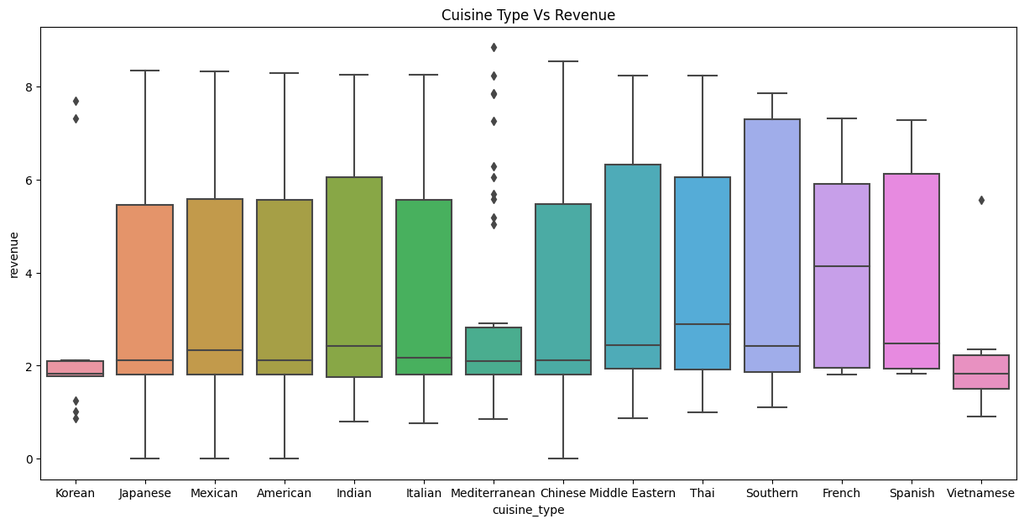

```python
weekend_revenue = df[df['day_of_the_week'] == 'Weekend']['revenue'].sum()
weekday_revenue = df[df['day_of_the_week'] == 'Weekday']['revenue'].sum()
print(weekend_revenue)
print(weekday_revenue)

plt.figure(figsize = (15, 7))
plt.title("Cuisine Type Vs Revenue")
sns.boxplot(data = df, x = "cuisine_type", y = "revenue")
plt.show()
```

### Recommendations:

There are two approaches that might make sense, based on the data:

#### Approach 1: Lean into the trends we're seeing in our user base to drive revenue

- Provide deals, discounts, etc. on the weekend, similar to something like Uber Eats or PostMates, because we get significantly more orders/activity during that timeframe
- We know from the graphs that we sell American, Japanese, Chinese and Italian foods the most, so we promote those foods as much as we can, offering discounts or putting the closest restaurants that offer those cuisines on the home page of the user to make them as accessible as possible

#### Approach 2: Try and drive more sales to the underutilized days of the week/cuisines to drive revenue

- We can try to drive more activity to the app during the week (deals, discounts, etc.) when we get less orders to try and get more people active on the app during the week as opposed to the weekend.
- We can also focus on promoting more expensive cuisines on the weekends, as that's when customers are more active. We can tell from the data that people are likely going to order American, Japanese, Italian and Chinese food regardless, just looking at the order counts by cuisine type. However, Southern, Middle Eastern, French, Indian, Spanish and Thai cuisines tend to make us more money, and have significantly lower order counts when we look at the cuisine_type countplot. To that end, we should place less emphasis on American, Japanese, Chinese and Italian restaurants during the weekend (people are likely to order those anyway if that's what they really want) and place more emphasis on these less-ordered cuisines in an effort to increase revenue.

### Conclusion:

In general, I would personally recommend approach 1, as it seems the safer option. Although there may be more upside with the second approach, there is a chance that people just don't order out as much on the weekdays, or they simply won't order the less-ordered cuisines because they're more expensive or they don't like them as much. If that's the case, approach 2 won't help us increase revenue much at all, and may even hurt us by placing less of an emphasis on the time we get the most orders (weekend) and the cuisines we sell the most (American, Italian, etc.).

However, I would recommend they do some focus testing with each approach to see what works, because if approach 2 goes well, that seems like the approach that would drive revenue the most.